# Using the ecoengine package

### Photos

The ecoengine also contains a large number of photos from various sources. It’s easy to query the photo database using similar arguments as above. One can search by taxa, location, source, collection and much more.

```r
photos <- ee_photos(quiet = TRUE, progress = FALSE)
photos
```

```
#>  [Total results on the server]: 74468
#>  [Args]:
#>  page_size = 1000
#>  georeferenced = 0
#>  page = 1
#>  [Type]: photos
#>  [Number of results retrieved]: 1000
```

The database currently holds 74468 photos. Photos can be searched by state province, county, genus, scientific name, authors along with date bounds. For additional options see `?ee_photos`.

#### Searching photos by author

```r
charles_results <- ee_photos(author = "Charles Webber", quiet = TRUE, progress = FALSE)
charles_results
```

```
#>  [Total results on the server]: 4907
#>  [Args]:
#>  page_size = 1000
#>  authors = Charles Webber
#>  georeferenced = FALSE
#>  page = 1
#>  [Type]: photos
#>  [Number of results retrieved]: 1000
```

```r
# Let's examine a couple of rows of the data
charles_results$data[1:2, ]
```

```
#>  Source: local data frame [2 x 18]
#>
#>                                                                            url
#>                                                                          (chr)
#>  1 https://ecoengine.berkeley.edu/api/photos/CalPhotos%3A0024%2B3291%2B2018%2B
#>  2 https://ecoengine.berkeley.edu/api/photos/CalPhotos%3A0024%2B3291%2B1998%2B
#>  Variables not shown: record (chr), authors (chr), locality (chr), county
#>    (chr), photog_notes (chr), begin_date (time), end_date (time),
#>    collection_code (chr), scientific_name (chr), url (chr), license (chr),
#>    media_url (chr), remote_resource (chr), source (chr), geometry.type
#>    (chr), longitude (chr), latitude (chr)
```

#### Browsing these photos

```r
view_photos(charles_results)
```

This will launch your default browser and render a page with thumbnails of all images returned by the search query. You can do this with any `ecoengine` object of type `photos`. Suggestions for improving the photo browser are welcome.

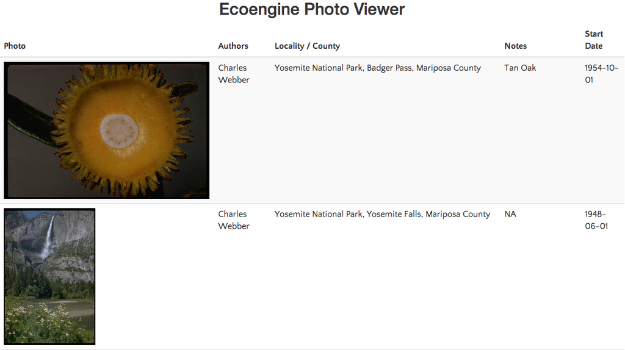

Other photo search examples

```r
# All the photos in the CDGA collection
all_cdfa <- ee_photos(collection_code = "CDFA", page = "all", progress = FALSE)
# All Racoon pictures
racoons <- ee_photos(scientific_name = "Procyon lotor", quiet = TRUE, progress = FALSE)
```

### Species checklists

There is a wealth of checklists from all the source locations. To get all available checklists from the engine, run:

```r
all_lists <- ee_checklists()
```

```
#>  Returning 52 checklists
```

```r
head(all_lists[, c("footprint", "subject")])
```

```
#>  Source: local data frame [6 x 2]
#>
#>                                                          footprint
#>                                                              (chr)
#>  1   https://ecoengine.berkeley.edu/api/footprints/angelo-reserve/
#>  2   https://ecoengine.berkeley.edu/api/footprints/angelo-reserve/
#>  3   https://ecoengine.berkeley.edu/api/footprints/angelo-reserve/
#>  4 https://ecoengine.berkeley.edu/api/footprints/hastings-reserve/
#>  5   https://ecoengine.berkeley.edu/api/footprints/angelo-reserve/
#>  6 https://ecoengine.berkeley.edu/api/footprints/hastings-reserve/
#>  Variables not shown: subject (chr)
```

Currently there are 52 lists available. We can drill deeper into any list to get all the available data. We can also narrow our checklist search to groups of interest (see `unique(all_lists$subject)`). For example, to get the list of Spiders:

```r
spiders <- ee_checklists(subject = "Spiders")
```

```
#>  Found 1 checklists
```

```r
spiders
```

```
#>  Source: local data frame [1 x 5]
#>
#>                  record
#>                   (chr)
#>  1 bigcb:specieslist:15
#>  Variables not shown: footprint (chr), url (chr), source (chr), subject
#>    (chr)
```

```r
library(plyr)
spider_details <- ldply(spiders$url, checklist_details)
names(spider_details)
```

```
#>   [1] "url"                              "observation_type"
#>   [3] "scientific_name"                  "collection_code"
#>   [5] "institution_code"                 "country"
#>   [7] "state_province"                   "county"
#>   [9] "locality"                         "begin_date"
#>  [11] "end_date"                         "kingdom"
#>  [13] "phylum"                           "clss"
#>  [15] "order"                            "family"
#>  [17] "genus"                            "specific_epithet"
#>  [19] "infraspecific_epithet"            "source"
#>  [21] "remote_resource"                  "earliest_period_or_lowest_system"
#>  [23] "latest_period_or_highest_system"
```

```r
unique(spider_details$scientific_name)
```

```
#>   [1] "Holocnemus pluchei"        "Oecobius navus"
#>   [3] "Uloborus diversus"         "Neriene litigiosa"
#>   [5] "Theridion "                "Tidarren "
#>   [7] "Dictyna "                  "Mallos "
#>   [9] "Yorima "                   "Hahnia sanjuanensis"
#>  [11] "Cybaeus "                  "Zanomys "
#>  [13] "Anachemmis "               "Titiotus "
#>  [15] "Oxyopes scalaris"          "Zora hespera"
#>  [17] "Drassinella "              "Phrurotimpus mateonus"
#>  [19] "Scotinella "               "Castianeira luctifera"
#>  [21] "Meriola californica"       "Drassyllus insularis"
#>  [23] "Herpyllus propinquus"      "Micaria utahna"
#>  [25] "Trachyzelotes lyonneti"    "Ebo evansae"
#>  [27] "Habronattus oregonensis"   "Metaphidippus "
#>  [29] "Platycryptus californicus" "Calymmaria "
#>  [31] "Frontinella communis"      "Undetermined "
#>  [33] "Latrodectus hesperus"
```

Our resulting dataset now contains 33 unique spider species.

### Searching the engine

The search is elastic by default. One can search for any field in `ee_observations()` across all available resources. For example,

```r
# The search function runs an automatic elastic search across all resources
# available through the engine.
lynx_results <- ee_search(query = "genus:Lynx")
lynx_results[, -3]
# This gives you a breakdown of what's available allowing you dig deeper.
```

Table continues below

| state_province | kingdom | genus | resource | family | scientific_name | country | clss | order |
| --- | --- | --- | --- | --- | --- | --- | --- | --- |

| phylum | georeferenced | observation_type | decade |
| --- | --- | --- | --- |

Table continues below

| field | results |
| --- | --- |
| California | 470 |
| Nevada | 105 |
| Alaska | 82 |
| British Columbia | 47 |
| Arizona | 36 |
| Baja California Sur | 25 |
| Montana | 19 |
| Baja California | 16 |
| New Mexico | 14 |
| Oregon | 13 |

| search_url |
| --- |
| https://ecoengine.berkeley.edu/api/search/?q=genus%3ALynx&selected_facets=state_province_exact%3A%22California%22 |
| https://ecoengine.berkeley.edu/api/search/?q=genus%3ALynx&selected_facets=state_province_exact%3A%22Nevada%22 |
| https://ecoengine.berkeley.edu/api/search/?q=genus%3ALynx&selected_facets=state_province_exact%3A%22Alaska%22 |
| https://ecoengine.berkeley.edu/api/search/?q=genus%3ALynx&selected_facets=state_province_exact%3A%22British+Columbia%22 |
| https://ecoengine.berkeley.edu/api/search/?q=genus%3ALynx&selected_facets=state_province_exact%3A%22Arizona%22 |
| https://ecoengine.berkeley.edu/api/search/?q=genus%3ALynx&selected_facets=state_province_exact%3A%22Baja+California+Sur%22 |
| https://ecoengine.berkeley.edu/api/search/?q=genus%3ALynx&selected_facets=state_province_exact%3A%22Montana%22 |
| https://ecoengine.berkeley.edu/api/search/?q=genus%3ALynx&selected_facets=state_province_exact%3A%22Baja+California%22 |
| https://ecoengine.berkeley.edu/api/search/?q=genus%3ALynx&selected_facets=state_province_exact%3A%22New+Mexico%22 |
| https://ecoengine.berkeley.edu/api/search/?q=genus%3ALynx&selected_facets=state_province_exact%3A%22Oregon%22 |

Similarly it’s possible to search through the observations in a detailed manner as well.

```r
all_lynx_data <- ee_search_obs(query = "Lynx", page = "all", progress = FALSE)
```

```
#>  Search contains 1033 observations (downloading 2 of 2 pages)
```

```r
all_lynx_data
```

```
#>  [Total results on the server]: 1033
#>  [Args]:
#>  q = Lynx
#>  page_size = 1000
#>  page = all
#>  [Type]: observations
#>  [Number of results retrieved]: 1000
```

### Miscellaneous functions

**Footprints**

`ee_footprints()` provides a list of all the footprints.

```r
footprints <- ee_footprints()
footprints[, -3]  # To keep the table from spilling over
```

Table continues below

| name |
| --- |
| Angelo Reserve |
| Sagehen Reserve |
| Hastings Reserve |
| Blue Oak Ranch Reserve |

| url |
| --- |
| https://ecoengine.berkeley.edu/api/footprints/angelo-reserve/ |
| https://ecoengine.berkeley.edu/api/footprints/sagehen-reserve/ |
| https://ecoengine.berkeley.edu/api/footprints/hastings-reserve/ |
| https://ecoengine.berkeley.edu/api/footprints/blue-oak-ranch-reserve/ |

**Data sources**

`ee_sources()` provides a list of data sources for the specimens contained in the museum.

```r
source_list <- ee_sources()
unique(source_list$name)
```

| name |
| --- |
| MVZ Birds |
| LACM Vertebrate Collection |
| CAS Botany |
| CAS Entomology |
| Consortium of California Herbaria |
| CAS Herpetology |
| CAS Ichthyology |
| CAS Ornithology |
| CalPhotos |
| BIGCB Sensors |

```
#>   setting  value
#>   version  R version 3.3.0 (2016-05-03)
#>   system   x86_64, darwin13.4.0
#>   ui       X11
#>   language (EN)
#>   collate  en_US.UTF-8
#>   tz       America/Los_Angeles
#>   date     2016-06-23
```

```
#>  Packages ------------------------------------------------------------------
```

[output not shown]

Please send any comments, questions, or ideas for new functionality or improvements to <karthik.ram@berkeley.edu>. The code lives on GitHub [under the rOpenSci account](https://github.com/ropensci/ecoengine). Pull requests and [bug reports](https://github.com/ropensci/ecoengine/issues?state=open) are most welcome.

Karthik Ram  
Jun, 2016  
*Berkeley, California*